# Interim Report: Portfolio Optimization — Data Exploration & Analysis

**Project:** Time Series Forecasting for Portfolio Management Optimization  
**Client:** Guide Me in Finance (GMF) Investments  
**Date:** July 5, 2026  
**Team:** Kerod, Mahbubah, Feven

```
Data loaded successfully.
```

## 1. Data Extraction and Cleaning

### 1.1 Data Source and Scope

Historical financial data was extracted from the **YFinance API** for three assets selected to represent different risk profiles:

| Asset | Ticker | Description | Risk Profile |
| --- | --- | --- | --- |
| Tesla | TSLA | High-growth automobile manufacturer | High risk, high potential return |
| Vanguard Total Bond Market ETF | BND | Tracks U.S. investment-grade bonds | Low risk, stability and income |
| S&P 500 ETF | SPY | Tracks the S&P 500 Index | Moderate risk, broad market exposure |

**Coverage period:** January 1, 2015 to June 30, 2026 (~11.5 years)

```
DATASET OVERVIEW
=================================================================
Asset      Rows   Cols     Start Date       End Date  Missing
-----------------------------------------------------------------
TSLA       2888      6     2015-01-02     2026-06-29        0
BND        2888      6     2015-01-02     2026-06-29        0
SPY        2888      6     2015-01-02     2026-06-29        0
=================================================================

Total trading days: 2888
Fields per asset: Open, High, Low, Close, Adj Close, Volume
```

### 1.2 Cleaning Steps Performed

| Step | Action | Result |
| --- | --- | --- |
| Missing value check | Scanned all columns for NaN/null values | No missing values found in any of the three datasets |
| Data type validation | Verified all price columns are float64, index is DatetimeIndex | All types correct; indices are monotonically increasing |
| Temporal alignment | Checked that all three assets share the same trading dates | 2,888 common trading days |
| Derived features | Computed daily percentage returns: `pct_change()` | Created `daily_returns` DataFrame (2,887 rows after dropping first NaN) |
| Data storage | Saved processed CSVs to `data/processed/` | Individual raw CSVs + combined close prices + daily returns |

## 2. Key EDA Visualizations and Insights

### 2.1 Closing Price Trends

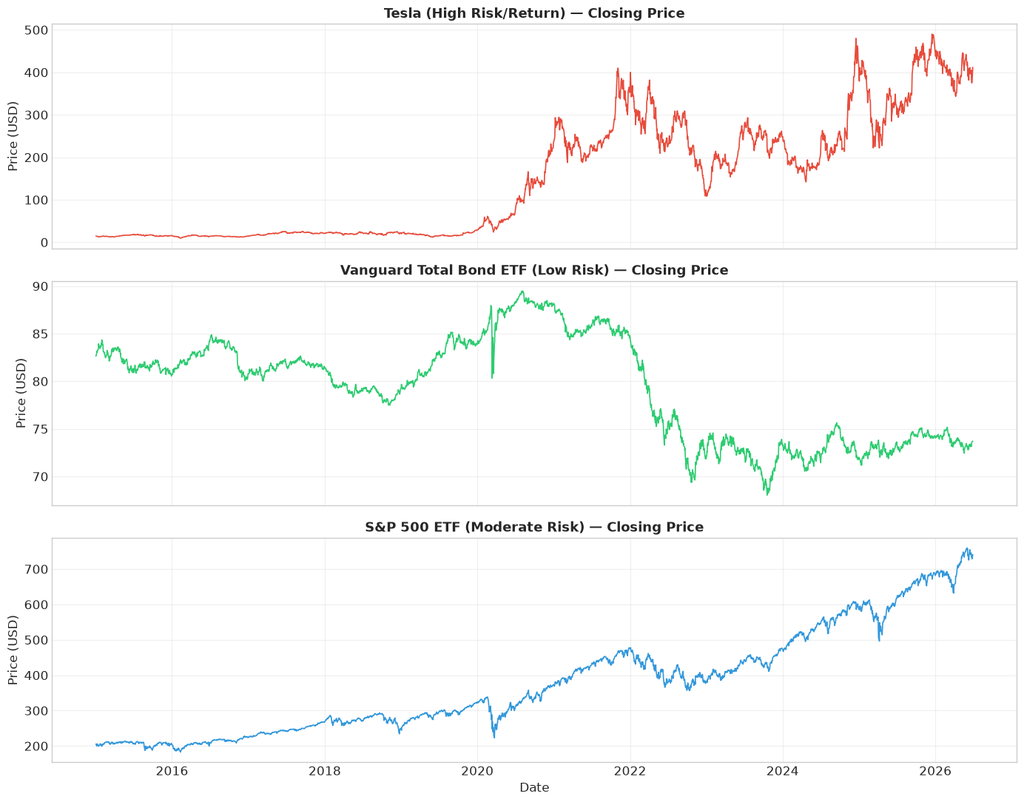

**Key observations:**

- **TSLA** exhibits an explosive growth trajectory, rallying from ~$10 in 2015 to peaks near $490. The most dramatic appreciation occurred during 2020-2021 (EV market enthusiasm, S&P 500 inclusion). Equally striking are the sharp drawdowns — the price is highly volatile and non-linear.
- **BND** trades in a narrow band ($68–$89), consistent with its investment-grade bond composition. The most notable move was the 2022 drawdown as rising interest rates pressured bond prices, followed by gradual recovery.
- **SPY** follows a steady upward trend reflecting broad U.S. equity market growth, punctuated by the COVID-19 crash (March 2020) and the 2022 bear market. The consistent upward trend makes it the natural benchmark.

### 2.2 Normalized Performance Comparison

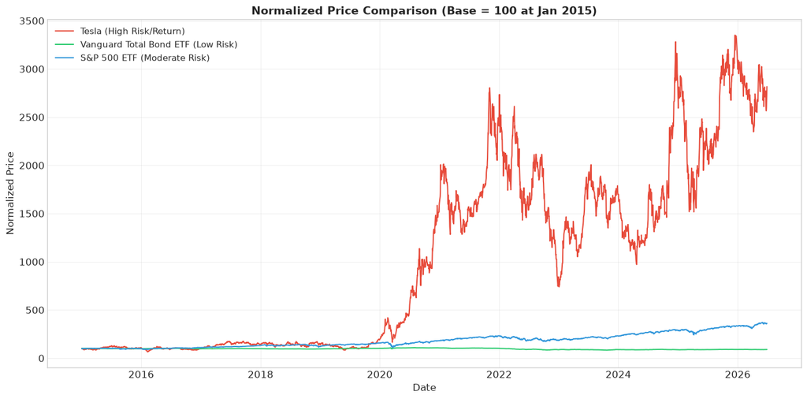

```
Total return over full period (Jan 2015 - Jun 2026):
  TSLA: +2716.8%
  BND: -10.8%
  SPY: +260.7%
```

**Insight:** Normalizing to a common base of 100 reveals the stark difference in total returns. TSLA has massively outperformed the other two assets in absolute terms, but with far greater volatility. BND barely moved, and SPY delivered steady compounding. This three-asset mix provides a strong spread of risk-return profiles for portfolio construction.

### 2.3 Daily Return Distributions

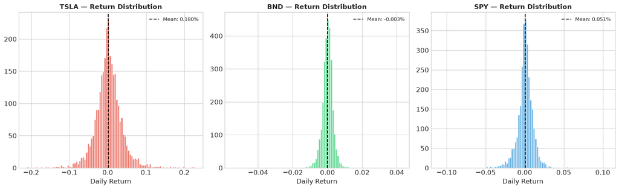

```
Daily Return Statistics:
              TSLA          BND          SPY
count  2887.000000  2887.000000  2887.000000
mean      0.001803    -0.000034     0.000507
std       0.036018     0.003383     0.011163
min      -0.210628    -0.054385    -0.109424
25%      -0.016643    -0.001635    -0.003772
50%       0.001216     0.000119     0.000603
75%       0.019456     0.001715     0.005920
max       0.226900     0.042201     0.105019
```

**Insight:** All three distributions are roughly bell-shaped but deviate from normality — they exhibit **fat tails** (high kurtosis), meaning extreme returns occur more often than a normal distribution predicts. TSLA's distribution is widest (highest variance), while BND's is tightly concentrated near zero. This fat-tail characteristic is critical for risk modeling: VaR estimates based on a normal assumption will *underestimate* tail risk.

### 2.4 Correlation Between Assets

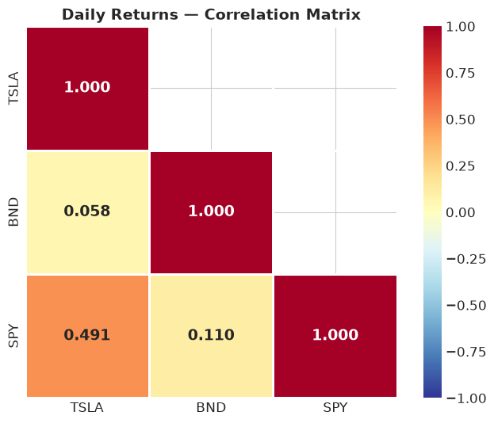

**Correlation findings:**

[output not shown]

**Portfolio implication:** These low-to-moderate correlations confirm that combining all three assets can meaningfully reduce portfolio variance — a prerequisite for efficient frontier optimization.

## 3. Stationarity Test Results and Interpretation

### 3.1 Augmented Dickey-Fuller (ADF) Test

Stationarity — where the statistical properties (mean, variance) of a series remain constant over time — is a fundamental requirement for ARIMA-family models.

- **H0 (Null):** The series has a unit root (non-stationary).
- **H1 (Alternative):** The series is stationary.
- **Decision rule:** Reject H0 if p-value < 0.05.

```
Augmented Dickey-Fuller Test Results
=====================================================================================
            Series  ADF Statistic  p-value  Critical 1%  Critical 5% Stationary?
  TSLA Close Price        -1.0696 0.727042      -3.4326      -2.8626          No
   BND Close Price        -1.0362 0.739841      -3.4326      -2.8625          No
   SPY Close Price         0.9918 0.994179      -3.4326      -2.8625          No
TSLA Daily Returns       -53.9719 0.000000      -3.4326      -2.8625         Yes
 BND Daily Returns       -15.2964 0.000000      -3.4326      -2.8625         Yes
 SPY Daily Returns       -17.4905 0.000000      -3.4326      -2.8625         Yes
=====================================================================================
```

### 3.2 Interpretation

**Closing prices (raw):**

- All three assets fail the ADF test (p-values 0.73–0.99) — they are **non-stationary**.
- This is expected: asset prices exhibit trends and their mean drifts over time.
- SPY has the highest p-value (0.994) reflecting its strong, persistent upward trend.

**Daily returns (first difference):**

- All three pass emphatically (p ≈ 0.000000, ADF statistics far below all critical values) — they are **stationary**.
- First-order differencing successfully removes the trend.

**Implication for modeling:**

- ARIMA models require **d ≥ 1** (at least one differencing step) to make prices stationary before fitting the AR and MA components.
- The daily returns series is suitable for direct modeling without further transformation.
- For the LSTM model, we scale the raw prices with MinMaxScaler instead of differencing, since neural networks can learn non-stationary patterns given sufficient capacity.

### 3.3 Seasonal Decomposition

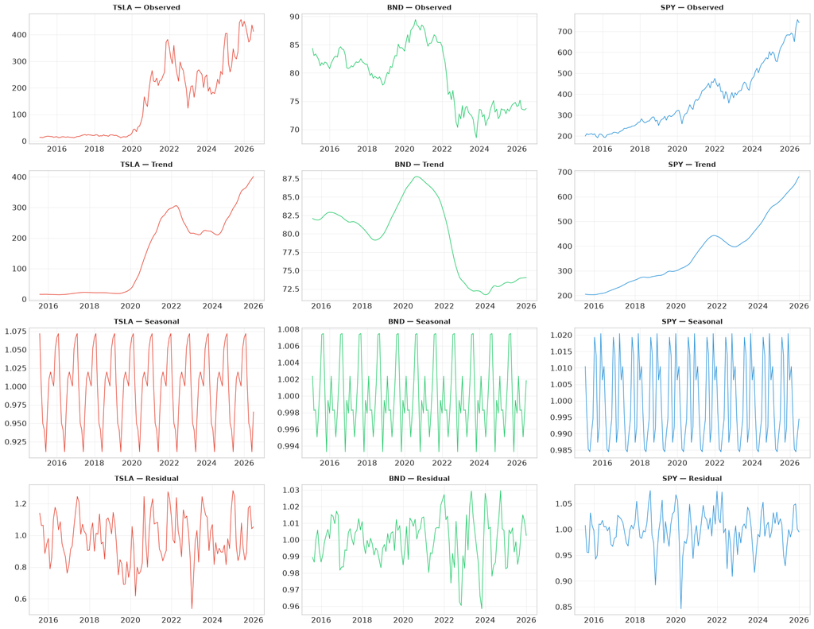

## 4. Volatility Analysis and Risk Metrics

### 4.1 Rolling Volatility (30-Day Window)

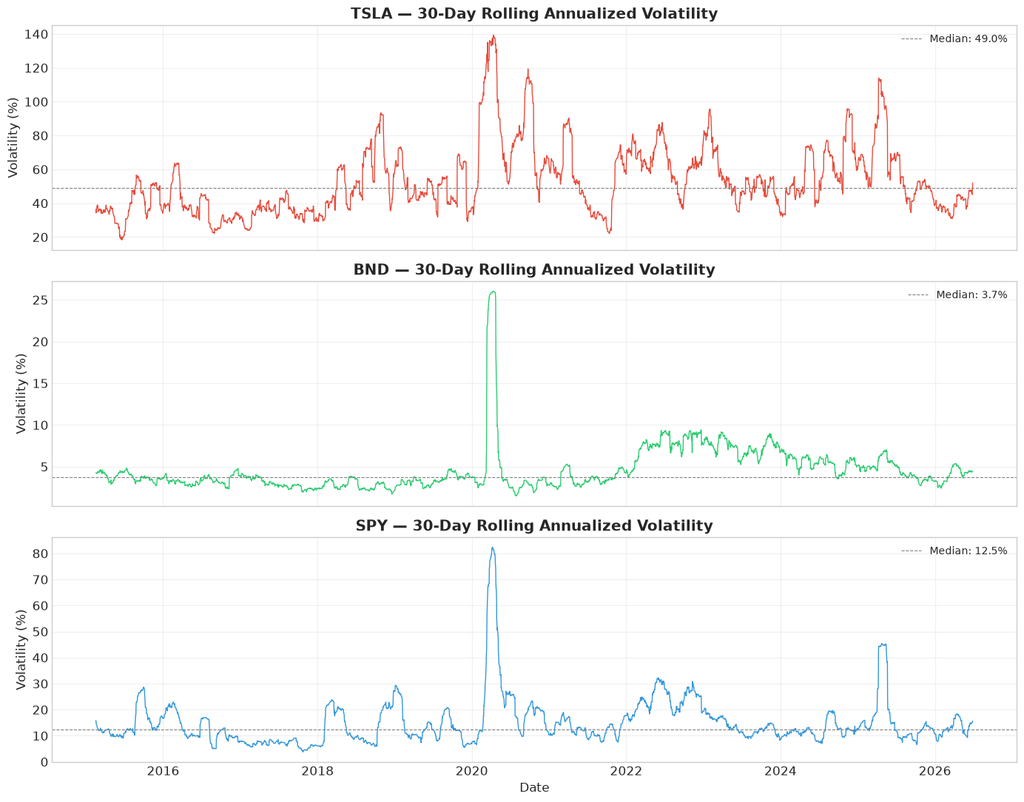

### 4.2 Outlier Analysis

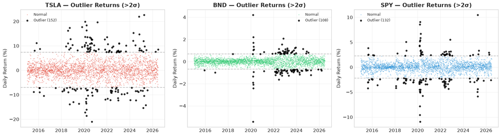

```
Outlier Summary (returns beyond 2 standard deviations):
---------------------------------------------------------------------------
Asset     Outlier Days  % of Total     Largest Up   Largest Down
---------------------------------------------------------------------------
TSLA               152        5.3%        +22.69%        -21.06%
BND                108        3.7%         +4.22%         -5.44%
SPY                132        4.6%        +10.50%        -10.94%
---------------------------------------------------------------------------
```

### 4.3 Comprehensive Risk Metrics

```
COMPREHENSIVE RISK METRICS
Risk-free rate assumption: 4.0% annual
===============================================================================================
Asset Ann. Return Ann. Volatility Sharpe Ratio Sortino Ratio VaR 95% Max Drawdown Skewness Kurtosis
 TSLA      45.42%          57.18%        0.724         1.073 -5.166%      -73.63%   0.2934     4.47
  BND      -0.85%           5.37%       -0.904        -1.138 -0.508%      -23.96%  -0.9126    34.86
  SPY      12.77%          17.72%        0.495         0.606 -1.674%      -34.10%  -0.3095    13.84
===============================================================================================
```

### 4.4 Risk Metrics Interpretation

#### Value at Risk (VaR) — 95% Confidence

| Asset | Daily VaR (95%) | Meaning |
| --- | --- | --- |
| TSLA | -5.17% | On any given day, there is a 5% chance of losing more than 5.17%. For a $10,000 position, the worst expected daily loss is $517. |
| SPY | -1.67% | Maximum expected daily loss is 1.67% ($167 per $10,000). |
| BND | -0.51% | Maximum expected daily loss is only 0.51% ($51 per $10,000). |

TSLA's VaR is **~10x that of BND** and **~3x that of SPY**, quantifying the risk premium investors bear for Tesla's higher expected returns.

#### Sharpe Ratio (Risk-Adjusted Returns)

| Asset | Sharpe | Assessment |
| --- | --- | --- |
| TSLA | 0.724 | Positive and highest of the three — the high volatility is compensated by even higher returns. |
| SPY | 0.495 | Decent risk-adjusted performance, consistent with long-term equity market averages. |
| BND | -0.904 | Negative — over this period, bonds underperformed the risk-free rate after adjusting for their (small) volatility. The 2022 bond drawdown drove this. |

#### Maximum Drawdown

| Asset | Max Drawdown | Context |
| --- | --- | --- |
| TSLA | -73.63% | From peak to trough, Tesla lost nearly three-quarters of its value — a devastating loss for concentrated positions. |
| SPY | -34.10% | The COVID-19 crash drove the deepest drawdown, consistent with historical bear market magnitudes. |
| BND | -23.96% | Unusually deep for bonds, driven by the aggressive 2022 rate hiking cycle. |

#### Distribution Shape (Skewness & Kurtosis)

| Asset | Skewness | Kurtosis | Implication |
| --- | --- | --- | --- |
| TSLA | +0.29 | 4.47 | Slight positive skew (more extreme gains than losses). Heavy tails — extreme events occur ~4.5x more frequently than normal. |
| BND | -0.91 | 34.86 | Strongly negatively skewed (crash risk) with *extremely* heavy tails — the March 2020 bond market disruption created rare but massive outliers. |
| SPY | -0.31 | 13.84 | Mild negative skew (market crashes). Very heavy tails — consistent with well-documented equity market behavior. |

### 4.5 Cumulative Returns and Drawdown

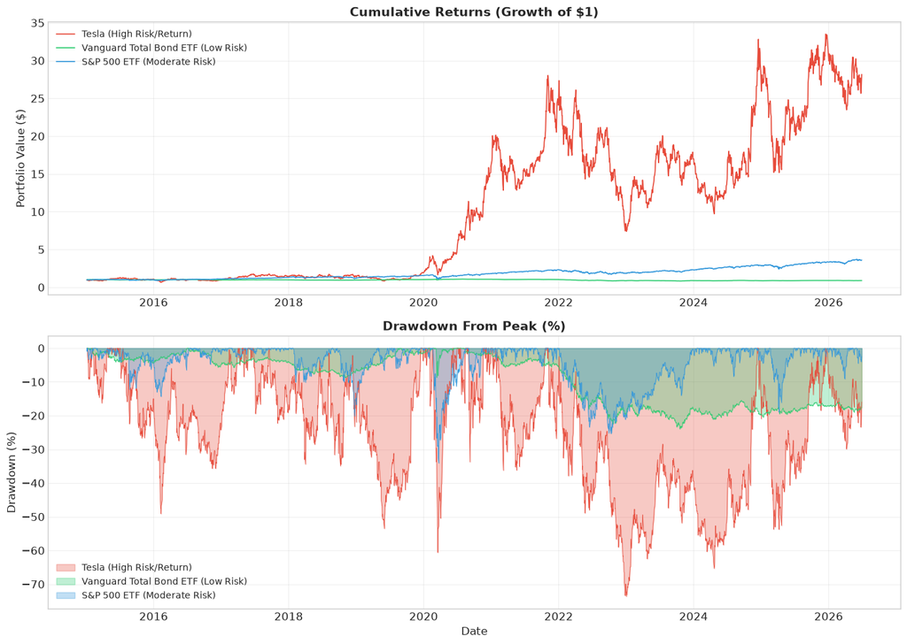

## 5. Summary and Next Steps

### Key Findings

1. **Data quality is clean** — 2,888 trading days with no missing values across all three assets, covering the full Jan 2015 – Jun 2026 window.
2. **Stationarity confirmed the need for differencing** — raw prices are non-stationary (p > 0.72), while daily returns are stationary (p ≈ 0). This directly informs ARIMA model specification (d ≥ 1).
3. **TSLA dominates in both return and risk** — annualized return of 45.4% comes with 57.2% volatility and a max drawdown of -73.6%. The Sharpe ratio of 0.72 shows the return compensates for risk, but the drawdown magnitude makes it unsuitable as a standalone holding.
4. **Low cross-asset correlations enable diversification** — TSLA–BND correlation of 0.058 and SPY–BND of 0.110 mean bonds genuinely reduce portfolio variance. This is the core premise for efficient frontier optimization.
5. **Fat-tailed distributions are universal** — kurtosis values of 4.5 (TSLA), 13.8 (SPY), and 34.9 (BND) mean normal-distribution assumptions underestimate tail risk. Parametric VaR should be supplemented with historical VaR.

### Next Steps (Final Submission)

- Portfolio optimization using the Efficient Frontier (PyPortfolioOpt)
- Integrate forecast-based expected returns into optimization
- Backtesting simulation of the optimized portfolio strategy
- Benchmark comparison (equal-weight vs. optimized vs. SPY)
- Final investment memo for stakeholders